# Risk Factor Analysis

## Outcome Variable

**Outcome Variable:** ever_swasted

## Predictor Variables

**Intervention Variable:** hhwealth_quart

**Adjustment Set:**

unadjusted

## Stratifying Variables

The analysis was stratified on these variable(s):

- agecat
- studyid
- country

## Data Summary

| agecat | studyid | country | hhwealth_quart | ever_swasted | n_cell | n |
| --- | --- | --- | --- | --- | --- | --- |
| 0-24 months | ki0047075b-MAL-ED | BANGLADESH | Wealth Q4 | 0 | 20 | 82 |
| 0-24 months | ki0047075b-MAL-ED | BANGLADESH | Wealth Q4 | 1 | 1 | 82 |
| 0-24 months | ki0047075b-MAL-ED | BANGLADESH | Wealth Q1 | 0 | 19 | 82 |
| 0-24 months | ki0047075b-MAL-ED | BANGLADESH | Wealth Q1 | 1 | 2 | 82 |
| 0-24 months | ki0047075b-MAL-ED | BANGLADESH | Wealth Q2 | 0 | 15 | 82 |
| 0-24 months | ki0047075b-MAL-ED | BANGLADESH | Wealth Q2 | 1 | 5 | 82 |
| 0-24 months | ki0047075b-MAL-ED | BANGLADESH | Wealth Q3 | 0 | 19 | 82 |
| 0-24 months | ki0047075b-MAL-ED | BANGLADESH | Wealth Q3 | 1 | 1 | 82 |
| 0-24 months | ki0047075b-MAL-ED | INDIA | Wealth Q4 | 0 | 17 | 71 |
| 0-24 months | ki0047075b-MAL-ED | INDIA | Wealth Q4 | 1 | 1 | 71 |
| 0-24 months | ki0047075b-MAL-ED | INDIA | Wealth Q1 | 0 | 14 | 71 |
| 0-24 months | ki0047075b-MAL-ED | INDIA | Wealth Q1 | 1 | 5 | 71 |
| 0-24 months | ki0047075b-MAL-ED | INDIA | Wealth Q2 | 0 | 14 | 71 |
| 0-24 months | ki0047075b-MAL-ED | INDIA | Wealth Q2 | 1 | 3 | 71 |
| 0-24 months | ki0047075b-MAL-ED | INDIA | Wealth Q3 | 0 | 14 | 71 |
| 0-24 months | ki0047075b-MAL-ED | INDIA | Wealth Q3 | 1 | 3 | 71 |
| 0-24 months | ki0047075b-MAL-ED | NEPAL | Wealth Q4 | 0 | 11 | 42 |
| 0-24 months | ki0047075b-MAL-ED | NEPAL | Wealth Q4 | 1 | 0 | 42 |
| 0-24 months | ki0047075b-MAL-ED | NEPAL | Wealth Q1 | 0 | 10 | 42 |
| 0-24 months | ki0047075b-MAL-ED | NEPAL | Wealth Q1 | 1 | 1 | 42 |
| 0-24 months | ki0047075b-MAL-ED | NEPAL | Wealth Q2 | 0 | 9 | 42 |
| 0-24 months | ki0047075b-MAL-ED | NEPAL | Wealth Q2 | 1 | 1 | 42 |
| 0-24 months | ki0047075b-MAL-ED | NEPAL | Wealth Q3 | 0 | 10 | 42 |
| 0-24 months | ki0047075b-MAL-ED | NEPAL | Wealth Q3 | 1 | 0 | 42 |
| 0-24 months | ki0047075b-MAL-ED | PERU | Wealth Q4 | 0 | 10 | 37 |
| 0-24 months | ki0047075b-MAL-ED | PERU | Wealth Q4 | 1 | 0 | 37 |
| 0-24 months | ki0047075b-MAL-ED | PERU | Wealth Q1 | 0 | 9 | 37 |
| 0-24 months | ki0047075b-MAL-ED | PERU | Wealth Q1 | 1 | 0 | 37 |
| 0-24 months | ki0047075b-MAL-ED | PERU | Wealth Q2 | 0 | 9 | 37 |
| 0-24 months | ki0047075b-MAL-ED | PERU | Wealth Q2 | 1 | 0 | 37 |

[output cut: 378 more lines]

The following strata were considered:

- agecat: 0-24 months, studyid: ki0047075b-MAL-ED, country: BANGLADESH
- agecat: 0-24 months, studyid: ki0047075b-MAL-ED, country: INDIA
- agecat: 0-24 months, studyid: ki0047075b-MAL-ED, country: NEPAL
- agecat: 0-24 months, studyid: ki0047075b-MAL-ED, country: PERU
- agecat: 0-24 months, studyid: ki0047075b-MAL-ED, country: SOUTH AFRICA
- agecat: 0-24 months, studyid: ki0047075b-MAL-ED, country: TANZANIA, UNITED REPUBLIC OF
- agecat: 0-24 months, studyid: ki1000108-CMC-V-BCS-2002, country: INDIA
- agecat: 0-24 months, studyid: ki1000108-IRC, country: INDIA
- agecat: 0-24 months, studyid: ki1017093b-PROVIDE, country: BANGLADESH
- agecat: 0-24 months, studyid: ki1066203-TanzaniaChild2, country: TANZANIA, UNITED REPUBLIC OF
- agecat: 0-24 months, studyid: ki1113344-GMS-Nepal, country: NEPAL
- agecat: 0-24 months, studyid: ki1114097-CONTENT, country: PERU
- agecat: 0-24 months, studyid: ki1135781-COHORTS, country: GUATEMALA
- agecat: 0-24 months, studyid: ki1135781-COHORTS, country: PHILIPPINES
- agecat: 0-24 months, studyid: ki1148112-LCNI-5, country: MALAWI
- agecat: 0-24 months, studyid: kiGH5241-JiVitA-3, country: BANGLADESH
- agecat: 0-24 months, studyid: kiGH5241-JiVitA-4, country: BANGLADESH
- agecat: 0-6 months, studyid: ki0047075b-MAL-ED, country: BANGLADESH
- agecat: 0-6 months, studyid: ki0047075b-MAL-ED, country: INDIA
- agecat: 0-6 months, studyid: ki0047075b-MAL-ED, country: NEPAL
- agecat: 0-6 months, studyid: ki0047075b-MAL-ED, country: PERU
- agecat: 0-6 months, studyid: ki0047075b-MAL-ED, country: SOUTH AFRICA
- agecat: 0-6 months, studyid: ki0047075b-MAL-ED, country: TANZANIA, UNITED REPUBLIC OF
- agecat: 0-6 months, studyid: ki1000108-CMC-V-BCS-2002, country: INDIA
- agecat: 0-6 months, studyid: ki1000108-IRC, country: INDIA
- agecat: 0-6 months, studyid: ki1017093b-PROVIDE, country: BANGLADESH
- agecat: 0-6 months, studyid: ki1066203-TanzaniaChild2, country: TANZANIA, UNITED REPUBLIC OF
- agecat: 0-6 months, studyid: ki1113344-GMS-Nepal, country: NEPAL
- agecat: 0-6 months, studyid: ki1114097-CONTENT, country: PERU
- agecat: 0-6 months, studyid: ki1135781-COHORTS, country: GUATEMALA
- agecat: 0-6 months, studyid: ki1135781-COHORTS, country: PHILIPPINES
- agecat: 0-6 months, studyid: ki1148112-LCNI-5, country: MALAWI
- agecat: 0-6 months, studyid: kiGH5241-JiVitA-3, country: BANGLADESH
- agecat: 0-6 months, studyid: kiGH5241-JiVitA-4, country: BANGLADESH
- agecat: 6-24 months, studyid: ki0047075b-MAL-ED, country: BANGLADESH
- agecat: 6-24 months, studyid: ki0047075b-MAL-ED, country: INDIA
- agecat: 6-24 months, studyid: ki0047075b-MAL-ED, country: NEPAL
- agecat: 6-24 months, studyid: ki0047075b-MAL-ED, country: PERU
- agecat: 6-24 months, studyid: ki0047075b-MAL-ED, country: SOUTH AFRICA
- agecat: 6-24 months, studyid: ki0047075b-MAL-ED, country: TANZANIA, UNITED REPUBLIC OF
- agecat: 6-24 months, studyid: ki1000108-CMC-V-BCS-2002, country: INDIA
- agecat: 6-24 months, studyid: ki1000108-IRC, country: INDIA
- agecat: 6-24 months, studyid: ki1017093b-PROVIDE, country: BANGLADESH
- agecat: 6-24 months, studyid: ki1066203-TanzaniaChild2, country: TANZANIA, UNITED REPUBLIC OF
- agecat: 6-24 months, studyid: ki1113344-GMS-Nepal, country: NEPAL
- agecat: 6-24 months, studyid: ki1114097-CONTENT, country: PERU
- agecat: 6-24 months, studyid: ki1135781-COHORTS, country: GUATEMALA
- agecat: 6-24 months, studyid: ki1135781-COHORTS, country: PHILIPPINES
- agecat: 6-24 months, studyid: ki1148112-LCNI-5, country: MALAWI
- agecat: 6-24 months, studyid: kiGH5241-JiVitA-3, country: BANGLADESH
- agecat: 6-24 months, studyid: kiGH5241-JiVitA-4, country: BANGLADESH

### Dropped Strata

Some strata were dropped due to rare outcomes:

- agecat: 0-24 months, studyid: ki0047075b-MAL-ED, country: BANGLADESH
- agecat: 0-24 months, studyid: ki0047075b-MAL-ED, country: INDIA
- agecat: 0-24 months, studyid: ki0047075b-MAL-ED, country: NEPAL
- agecat: 0-24 months, studyid: ki0047075b-MAL-ED, country: PERU
- agecat: 0-24 months, studyid: ki0047075b-MAL-ED, country: SOUTH AFRICA
- agecat: 0-24 months, studyid: ki0047075b-MAL-ED, country: TANZANIA, UNITED REPUBLIC OF
- agecat: 0-24 months, studyid: ki1114097-CONTENT, country: PERU
- agecat: 0-24 months, studyid: ki1148112-LCNI-5, country: MALAWI
- agecat: 0-6 months, studyid: ki0047075b-MAL-ED, country: BANGLADESH
- agecat: 0-6 months, studyid: ki0047075b-MAL-ED, country: INDIA
- agecat: 0-6 months, studyid: ki0047075b-MAL-ED, country: NEPAL
- agecat: 0-6 months, studyid: ki0047075b-MAL-ED, country: PERU
- agecat: 0-6 months, studyid: ki0047075b-MAL-ED, country: SOUTH AFRICA
- agecat: 0-6 months, studyid: ki0047075b-MAL-ED, country: TANZANIA, UNITED REPUBLIC OF
- agecat: 0-6 months, studyid: ki1114097-CONTENT, country: PERU
- agecat: 0-6 months, studyid: ki1148112-LCNI-5, country: MALAWI
- agecat: 6-24 months, studyid: ki0047075b-MAL-ED, country: BANGLADESH
- agecat: 6-24 months, studyid: ki0047075b-MAL-ED, country: INDIA
- agecat: 6-24 months, studyid: ki0047075b-MAL-ED, country: NEPAL
- agecat: 6-24 months, studyid: ki0047075b-MAL-ED, country: PERU
- agecat: 6-24 months, studyid: ki0047075b-MAL-ED, country: SOUTH AFRICA
- agecat: 6-24 months, studyid: ki0047075b-MAL-ED, country: TANZANIA, UNITED REPUBLIC OF
- agecat: 6-24 months, studyid: ki1000108-CMC-V-BCS-2002, country: INDIA
- agecat: 6-24 months, studyid: ki1017093b-PROVIDE, country: BANGLADESH
- agecat: 6-24 months, studyid: ki1114097-CONTENT, country: PERU
- agecat: 6-24 months, studyid: ki1135781-COHORTS, country: GUATEMALA
- agecat: 6-24 months, studyid: ki1148112-LCNI-5, country: MALAWI

## Methods Detail

We’re interested in the causal parameters $E[Y_a]$ for all values of $a \in \mathcal{A}$. These parameters represent the mean outcome if, possibly contrary to fact, we intervened to set all units to have $A=a$. Under the randomization and positivity assumptions, these are identified by the statistical parameters $\psi_a=E_W[E_{Y|A,W}(Y|A=a,W)]$. In addition, we’re interested in the mean of $Y$, $E[Y]$ under no intervention (the observed mean). We will estimate these parameters by using SuperLearner to fit the relevant likelihood factors – $E_{Y|A,W}(Y|A=a,W)$ and $p(A=a|W)$, and then updating our likelihood fit using a joint TMLE.

For unadjusted analyses ($W=\{\}$), initial likelihoods were estimated using Lrnr_glm to estimate the simple $E(Y|A)$ and Lrnr_mean to estimate $p(A)$. For adjusted analyses, a small library containing Lrnr_glmnet, Lrnr_xgboost, and Lrnr_mean was used.

Having estimated these parameters, we will then use the delta method to estimate relative risks and attributable risks relative to a prespecified baseline level of $A$.

# Results Detail

## Results Plots

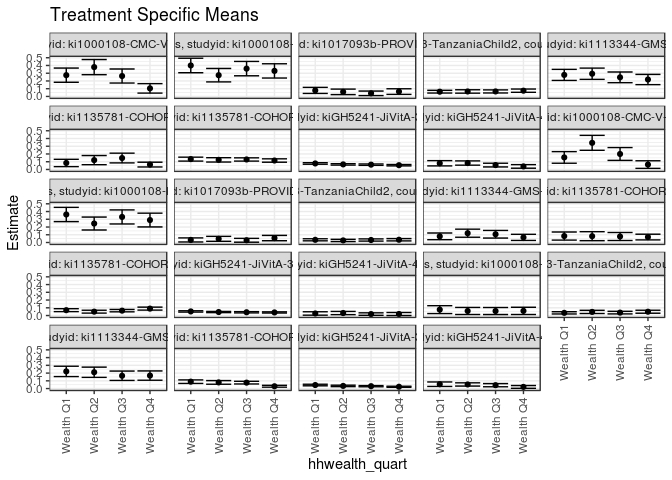

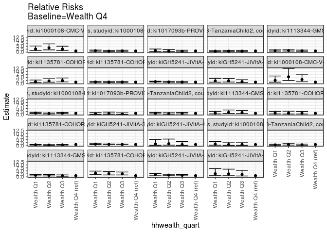

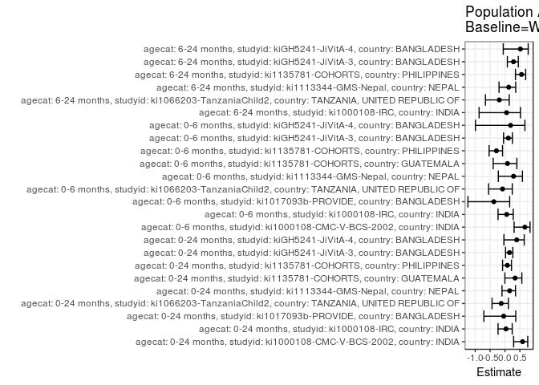

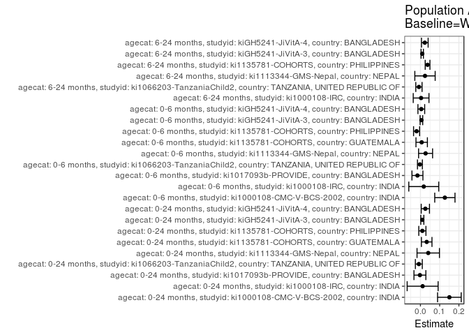

## Results Table

### Parameter: TSM

| agecat | studyid | country | intervention_level | baseline_level | estimate | ci_lower | ci_upper |
| --- | --- | --- | --- | --- | --- | --- | --- |
| 0-24 months | ki1000108-CMC-V-BCS-2002 | INDIA | Wealth Q4 | NA | 0.1041667 | 0.0429777 | 0.1653557 |
| 0-24 months | ki1000108-CMC-V-BCS-2002 | INDIA | Wealth Q1 | NA | 0.2747253 | 0.1828897 | 0.3665608 |
| 0-24 months | ki1000108-CMC-V-BCS-2002 | INDIA | Wealth Q2 | NA | 0.3789474 | 0.2812635 | 0.4766312 |
| 0-24 months | ki1000108-CMC-V-BCS-2002 | INDIA | Wealth Q3 | NA | 0.2637363 | 0.1730770 | 0.3543955 |
| 0-24 months | ki1000108-IRC | INDIA | Wealth Q4 | NA | 0.3300000 | 0.2377274 | 0.4222726 |
| 0-24 months | ki1000108-IRC | INDIA | Wealth Q1 | NA | 0.4000000 | 0.3061813 | 0.4938187 |
| 0-24 months | ki1000108-IRC | INDIA | Wealth Q2 | NA | 0.2745098 | 0.1877990 | 0.3612206 |
| 0-24 months | ki1000108-IRC | INDIA | Wealth Q3 | NA | 0.3592233 | 0.2664559 | 0.4519907 |
| 0-24 months | ki1017093b-PROVIDE | BANGLADESH | Wealth Q4 | NA | 0.0628571 | 0.0268722 | 0.0988421 |
| 0-24 months | ki1017093b-PROVIDE | BANGLADESH | Wealth Q1 | NA | 0.0777778 | 0.0386244 | 0.1169311 |
| 0-24 months | ki1017093b-PROVIDE | BANGLADESH | Wealth Q2 | NA | 0.0591716 | 0.0235734 | 0.0947698 |
| 0-24 months | ki1017093b-PROVIDE | BANGLADESH | Wealth Q3 | NA | 0.0402299 | 0.0110124 | 0.0694474 |
| 0-24 months | ki1066203-TanzaniaChild2 | TANZANIA, UNITED REPUBLIC OF | Wealth Q4 | NA | 0.0741990 | 0.0530996 | 0.0952984 |
| 0-24 months | ki1066203-TanzaniaChild2 | TANZANIA, UNITED REPUBLIC OF | Wealth Q1 | NA | 0.0611961 | 0.0436725 | 0.0787197 |
| 0-24 months | ki1066203-TanzaniaChild2 | TANZANIA, UNITED REPUBLIC OF | Wealth Q2 | NA | 0.0641822 | 0.0423213 | 0.0860431 |
| 0-24 months | ki1066203-TanzaniaChild2 | TANZANIA, UNITED REPUBLIC OF | Wealth Q3 | NA | 0.0645161 | 0.0446719 | 0.0843603 |
| 0-24 months | ki1113344-GMS-Nepal | NEPAL | Wealth Q4 | NA | 0.2185430 | 0.1525738 | 0.2845123 |
| 0-24 months | ki1113344-GMS-Nepal | NEPAL | Wealth Q1 | NA | 0.2781457 | 0.2066168 | 0.3496746 |
| 0-24 months | ki1113344-GMS-Nepal | NEPAL | Wealth Q2 | NA | 0.2933333 | 0.2204125 | 0.3662541 |
| 0-24 months | ki1113344-GMS-Nepal | NEPAL | Wealth Q3 | NA | 0.2466667 | 0.1776248 | 0.3157085 |
| 0-24 months | ki1135781-COHORTS | GUATEMALA | Wealth Q4 | NA | 0.0630252 | 0.0321266 | 0.0939238 |
| 0-24 months | ki1135781-COHORTS | GUATEMALA | Wealth Q1 | NA | 0.0839695 | 0.0364375 | 0.1315015 |
| 0-24 months | ki1135781-COHORTS | GUATEMALA | Wealth Q2 | NA | 0.1206897 | 0.0613584 | 0.1800209 |
| 0-24 months | ki1135781-COHORTS | GUATEMALA | Wealth Q3 | NA | 0.1475410 | 0.0845586 | 0.2105234 |
| 0-24 months | ki1135781-COHORTS | PHILIPPINES | Wealth Q4 | NA | 0.1154762 | 0.0938599 | 0.1370925 |
| 0-24 months | ki1135781-COHORTS | PHILIPPINES | Wealth Q1 | NA | 0.1336270 | 0.1080679 | 0.1591861 |
| 0-24 months | ki1135781-COHORTS | PHILIPPINES | Wealth Q2 | NA | 0.1240741 | 0.0962643 | 0.1518838 |
| 0-24 months | ki1135781-COHORTS | PHILIPPINES | Wealth Q3 | NA | 0.1291963 | 0.1082249 | 0.1501678 |
| 0-24 months | kiGH5241-JiVitA-3 | BANGLADESH | Wealth Q4 | NA | 0.0552470 | 0.0464375 | 0.0640565 |
| 0-24 months | kiGH5241-JiVitA-3 | BANGLADESH | Wealth Q1 | NA | 0.0775993 | 0.0675846 | 0.0876139 |

[output cut: 66 more lines]

### Parameter: E(Y)

| agecat | studyid | country | intervention_level | baseline_level | estimate | ci_lower | ci_upper |
| --- | --- | --- | --- | --- | --- | --- | --- |
| 0-24 months | ki1000108-CMC-V-BCS-2002 | INDIA | NA | NA | 0.2546917 | 0.2104174 | 0.2989660 |
| 0-24 months | ki1000108-IRC | INDIA | NA | NA | 0.3414634 | 0.2955068 | 0.3874201 |
| 0-24 months | ki1017093b-PROVIDE | BANGLADESH | NA | NA | 0.0601719 | 0.0425175 | 0.0778263 |
| 0-24 months | ki1066203-TanzaniaChild2 | TANZANIA, UNITED REPUBLIC OF | NA | NA | 0.0658557 | 0.0558973 | 0.0758141 |
| 0-24 months | ki1113344-GMS-Nepal | NEPAL | NA | NA | 0.2591362 | 0.2241059 | 0.2941665 |
| 0-24 months | ki1135781-COHORTS | GUATEMALA | NA | NA | 0.0955519 | 0.0721461 | 0.1189577 |
| 0-24 months | ki1135781-COHORTS | PHILIPPINES | NA | NA | 0.1254928 | 0.1137225 | 0.1372631 |
| 0-24 months | kiGH5241-JiVitA-3 | BANGLADESH | NA | NA | 0.0650443 | 0.0602009 | 0.0698877 |
| 0-24 months | kiGH5241-JiVitA-4 | BANGLADESH | NA | NA | 0.0649441 | 0.0516571 | 0.0782311 |
| 0-6 months | ki1000108-CMC-V-BCS-2002 | INDIA | NA | NA | 0.1902174 | 0.1500638 | 0.2303710 |
| 0-6 months | ki1000108-IRC | INDIA | NA | NA | 0.3073171 | 0.2626027 | 0.3520314 |
| 0-6 months | ki1017093b-PROVIDE | BANGLADESH | NA | NA | 0.0415473 | 0.0267327 | 0.0563618 |
| 0-6 months | ki1066203-TanzaniaChild2 | TANZANIA, UNITED REPUBLIC OF | NA | NA | 0.0327181 | 0.0255755 | 0.0398607 |
| 0-6 months | ki1113344-GMS-Nepal | NEPAL | NA | NA | 0.0930233 | 0.0698010 | 0.1162455 |
| 0-6 months | ki1135781-COHORTS | GUATEMALA | NA | NA | 0.0767635 | 0.0529727 | 0.1005543 |
| 0-6 months | ki1135781-COHORTS | PHILIPPINES | NA | NA | 0.0693395 | 0.0603122 | 0.0783667 |
| 0-6 months | kiGH5241-JiVitA-3 | BANGLADESH | NA | NA | 0.0450057 | 0.0407892 | 0.0492221 |
| 0-6 months | kiGH5241-JiVitA-4 | BANGLADESH | NA | NA | 0.0240783 | 0.0146594 | 0.0334971 |
| 6-24 months | ki1000108-IRC | INDIA | NA | NA | 0.0634146 | 0.0397960 | 0.0870333 |
| 6-24 months | ki1066203-TanzaniaChild2 | TANZANIA, UNITED REPUBLIC OF | NA | NA | 0.0412935 | 0.0325931 | 0.0499940 |
| 6-24 months | ki1113344-GMS-Nepal | NEPAL | NA | NA | 0.1915254 | 0.1597467 | 0.2233042 |
| 6-24 months | ki1135781-COHORTS | PHILIPPINES | NA | NA | 0.0669277 | 0.0576848 | 0.0761707 |
| 6-24 months | kiGH5241-JiVitA-3 | BANGLADESH | NA | NA | 0.0327524 | 0.0284767 | 0.0370280 |
| 6-24 months | kiGH5241-JiVitA-4 | BANGLADESH | NA | NA | 0.0440559 | 0.0331293 | 0.0549826 |

### Parameter: RR

| agecat | studyid | country | intervention_level | baseline_level | estimate | ci_lower | ci_upper |
| --- | --- | --- | --- | --- | --- | --- | --- |
| 0-24 months | ki1000108-CMC-V-BCS-2002 | INDIA | Wealth Q4 | Wealth Q4 | 1.0000000 | 1.0000000 | 1.0000000 |
| 0-24 months | ki1000108-CMC-V-BCS-2002 | INDIA | Wealth Q1 | Wealth Q4 | 2.6373626 | 1.3416627 | 5.1843741 |
| 0-24 months | ki1000108-CMC-V-BCS-2002 | INDIA | Wealth Q2 | Wealth Q4 | 3.6378947 | 1.9153853 | 6.9094598 |
| 0-24 months | ki1000108-CMC-V-BCS-2002 | INDIA | Wealth Q3 | Wealth Q4 | 2.5318681 | 1.2819151 | 5.0006091 |
| 0-24 months | ki1000108-IRC | INDIA | Wealth Q4 | Wealth Q4 | 1.0000000 | 1.0000000 | 1.0000000 |
| 0-24 months | ki1000108-IRC | INDIA | Wealth Q1 | Wealth Q4 | 1.2121212 | 0.8414838 | 1.7460085 |
| 0-24 months | ki1000108-IRC | INDIA | Wealth Q2 | Wealth Q4 | 0.8318479 | 0.5455506 | 1.2683901 |
| 0-24 months | ki1000108-IRC | INDIA | Wealth Q3 | Wealth Q4 | 1.0885555 | 0.7439572 | 1.5927703 |
| 0-24 months | ki1017093b-PROVIDE | BANGLADESH | Wealth Q4 | Wealth Q4 | 1.0000000 | 1.0000000 | 1.0000000 |
| 0-24 months | ki1017093b-PROVIDE | BANGLADESH | Wealth Q1 | Wealth Q4 | 1.2373737 | 0.5773290 | 2.6520300 |
| 0-24 months | ki1017093b-PROVIDE | BANGLADESH | Wealth Q2 | Wealth Q4 | 0.9413663 | 0.4102904 | 2.1598619 |
| 0-24 months | ki1017093b-PROVIDE | BANGLADESH | Wealth Q3 | Wealth Q4 | 0.6400210 | 0.2538468 | 1.6136777 |
| 0-24 months | ki1066203-TanzaniaChild2 | TANZANIA, UNITED REPUBLIC OF | Wealth Q4 | Wealth Q4 | 1.0000000 | 1.0000000 | 1.0000000 |
| 0-24 months | ki1066203-TanzaniaChild2 | TANZANIA, UNITED REPUBLIC OF | Wealth Q1 | Wealth Q4 | 0.8247566 | 0.5508872 | 1.2347782 |
| 0-24 months | ki1066203-TanzaniaChild2 | TANZANIA, UNITED REPUBLIC OF | Wealth Q2 | Wealth Q4 | 0.8650009 | 0.5550313 | 1.3480802 |
| 0-24 months | ki1066203-TanzaniaChild2 | TANZANIA, UNITED REPUBLIC OF | Wealth Q3 | Wealth Q4 | 0.8695015 | 0.5719365 | 1.3218823 |
| 0-24 months | ki1113344-GMS-Nepal | NEPAL | Wealth Q4 | Wealth Q4 | 1.0000000 | 1.0000000 | 1.0000000 |
| 0-24 months | ki1113344-GMS-Nepal | NEPAL | Wealth Q1 | Wealth Q4 | 1.2727273 | 0.8560828 | 1.8921473 |
| 0-24 months | ki1113344-GMS-Nepal | NEPAL | Wealth Q2 | Wealth Q4 | 1.3422222 | 0.9078097 | 1.9845135 |
| 0-24 months | ki1113344-GMS-Nepal | NEPAL | Wealth Q3 | Wealth Q4 | 1.1286869 | 0.7478121 | 1.7035484 |
| 0-24 months | ki1135781-COHORTS | GUATEMALA | Wealth Q4 | Wealth Q4 | 1.0000000 | 1.0000000 | 1.0000000 |
| 0-24 months | ki1135781-COHORTS | GUATEMALA | Wealth Q1 | Wealth Q4 | 1.3323155 | 0.6300639 | 2.8172771 |
| 0-24 months | ki1135781-COHORTS | GUATEMALA | Wealth Q2 | Wealth Q4 | 1.9149425 | 0.9563873 | 3.8342260 |
| 0-24 months | ki1135781-COHORTS | GUATEMALA | Wealth Q3 | Wealth Q4 | 2.3409836 | 1.2220255 | 4.4845251 |
| 0-24 months | ki1135781-COHORTS | PHILIPPINES | Wealth Q4 | Wealth Q4 | 1.0000000 | 1.0000000 | 1.0000000 |
| 0-24 months | ki1135781-COHORTS | PHILIPPINES | Wealth Q1 | Wealth Q4 | 1.1571824 | 0.8854652 | 1.5122799 |
| 0-24 months | ki1135781-COHORTS | PHILIPPINES | Wealth Q2 | Wealth Q4 | 1.0744559 | 0.8023494 | 1.4388439 |
| 0-24 months | ki1135781-COHORTS | PHILIPPINES | Wealth Q3 | Wealth Q4 | 1.1188136 | 0.8732790 | 1.4333837 |
| 0-24 months | kiGH5241-JiVitA-3 | BANGLADESH | Wealth Q4 | Wealth Q4 | 1.0000000 | 1.0000000 | 1.0000000 |
| 0-24 months | kiGH5241-JiVitA-3 | BANGLADESH | Wealth Q1 | Wealth Q4 | 1.4045879 | 1.1465786 | 1.7206558 |

[output cut: 66 more lines]

### Parameter: PAR

| agecat | studyid | country | intervention_level | baseline_level | estimate | ci_lower | ci_upper |
| --- | --- | --- | --- | --- | --- | --- | --- |
| 0-24 months | ki1000108-CMC-V-BCS-2002 | INDIA | Wealth Q4 | NA | 0.1505250 | 0.0890673 | 0.2119828 |
| 0-24 months | ki1000108-IRC | INDIA | Wealth Q4 | NA | 0.0114634 | -0.0689913 | 0.0919181 |
| 0-24 months | ki1017093b-PROVIDE | BANGLADESH | Wealth Q4 | NA | -0.0026852 | -0.0336252 | 0.0282547 |
| 0-24 months | ki1066203-TanzaniaChild2 | TANZANIA, UNITED REPUBLIC OF | Wealth Q4 | NA | -0.0083433 | -0.0263122 | 0.0096256 |
| 0-24 months | ki1113344-GMS-Nepal | NEPAL | Wealth Q4 | NA | 0.0405932 | -0.0176809 | 0.0988672 |
| 0-24 months | ki1135781-COHORTS | GUATEMALA | Wealth Q4 | NA | 0.0325267 | 0.0050699 | 0.0599835 |
| 0-24 months | ki1135781-COHORTS | PHILIPPINES | Wealth Q4 | NA | 0.0100166 | -0.0086360 | 0.0286692 |
| 0-24 months | kiGH5241-JiVitA-3 | BANGLADESH | Wealth Q4 | NA | 0.0097973 | 0.0018082 | 0.0177864 |
| 0-24 months | kiGH5241-JiVitA-4 | BANGLADESH | Wealth Q4 | NA | 0.0255502 | 0.0040693 | 0.0470311 |
| 0-6 months | ki1000108-CMC-V-BCS-2002 | INDIA | Wealth Q4 | NA | 0.1270595 | 0.0744026 | 0.1797164 |
| 0-6 months | ki1000108-IRC | INDIA | Wealth Q4 | NA | 0.0173171 | -0.0605323 | 0.0951664 |
| 0-6 months | ki1017093b-PROVIDE | BANGLADESH | Wealth Q4 | NA | -0.0155956 | -0.0440554 | 0.0128642 |
| 0-6 months | ki1066203-TanzaniaChild2 | TANZANIA, UNITED REPUBLIC OF | Wealth Q4 | NA | -0.0026950 | -0.0154332 | 0.0100432 |
| 0-6 months | ki1113344-GMS-Nepal | NEPAL | Wealth Q4 | NA | 0.0267981 | -0.0095965 | 0.0631927 |
| 0-6 months | ki1135781-COHORTS | GUATEMALA | Wealth Q4 | NA | 0.0064932 | -0.0232033 | 0.0361898 |
| 0-6 months | ki1135781-COHORTS | PHILIPPINES | Wealth Q4 | NA | -0.0199462 | -0.0356977 | -0.0041948 |
| 0-6 months | kiGH5241-JiVitA-3 | BANGLADESH | Wealth Q4 | NA | 0.0050644 | -0.0016832 | 0.0118119 |
| 0-6 months | kiGH5241-JiVitA-4 | BANGLADESH | Wealth Q4 | NA | 0.0045343 | -0.0130168 | 0.0220854 |
| 6-24 months | ki1000108-IRC | INDIA | Wealth Q4 | NA | 0.0034146 | -0.0374543 | 0.0442835 |
| 6-24 months | ki1066203-TanzaniaChild2 | TANZANIA, UNITED REPUBLIC OF | Wealth Q4 | NA | -0.0078868 | -0.0241703 | 0.0083967 |
| 6-24 months | ki1113344-GMS-Nepal | NEPAL | Wealth Q4 | NA | 0.0237402 | -0.0291237 | 0.0766041 |
| 6-24 months | ki1135781-COHORTS | PHILIPPINES | Wealth Q4 | NA | 0.0370963 | 0.0248287 | 0.0493640 |
| 6-24 months | kiGH5241-JiVitA-3 | BANGLADESH | Wealth Q4 | NA | 0.0093725 | 0.0033580 | 0.0153871 |
| 6-24 months | kiGH5241-JiVitA-4 | BANGLADESH | Wealth Q4 | NA | 0.0227793 | 0.0055372 | 0.0400215 |

### Parameter: PAF

| agecat | studyid | country | intervention_level | baseline_level | estimate | ci_lower | ci_upper |
| --- | --- | --- | --- | --- | --- | --- | --- |
| 0-24 months | ki1000108-CMC-V-BCS-2002 | INDIA | Wealth Q4 | NA | 0.5910088 | 0.2910303 | 0.7640607 |
| 0-24 months | ki1000108-IRC | INDIA | Wealth Q4 | NA | 0.0335714 | -0.2332518 | 0.2426655 |
| 0-24 months | ki1017093b-PROVIDE | BANGLADESH | Wealth Q4 | NA | -0.0446258 | -0.7087239 | 0.3613695 |
| 0-24 months | ki1066203-TanzaniaChild2 | TANZANIA, UNITED REPUBLIC OF | Wealth Q4 | NA | -0.1266904 | -0.4346973 | 0.1151923 |
| 0-24 months | ki1113344-GMS-Nepal | NEPAL | Wealth Q4 | NA | 0.1566480 | -0.1005301 | 0.3537272 |
| 0-24 months | ki1135781-COHORTS | GUATEMALA | Wealth Q4 | NA | 0.3404086 | -0.0034360 | 0.5664289 |
| 0-24 months | ki1135781-COHORTS | PHILIPPINES | Wealth Q4 | NA | 0.0798180 | -0.0813311 | 0.2169513 |
| 0-24 months | kiGH5241-JiVitA-3 | BANGLADESH | Wealth Q4 | NA | 0.1506252 | 0.0195075 | 0.2642089 |
| 0-24 months | kiGH5241-JiVitA-4 | BANGLADESH | Wealth Q4 | NA | 0.3934180 | -0.0362788 | 0.6449394 |
| 0-6 months | ki1000108-CMC-V-BCS-2002 | INDIA | Wealth Q4 | NA | 0.6679699 | 0.3062989 | 0.8410786 |
| 0-6 months | ki1000108-IRC | INDIA | Wealth Q4 | NA | 0.0563492 | -0.2342013 | 0.2784995 |
| 0-6 months | ki1017093b-PROVIDE | BANGLADESH | Wealth Q4 | NA | -0.3753695 | -1.2441425 | 0.1570762 |
| 0-6 months | ki1066203-TanzaniaChild2 | TANZANIA, UNITED REPUBLIC OF | Wealth Q4 | NA | -0.0823713 | -0.5503815 | 0.2443618 |
| 0-6 months | ki1113344-GMS-Nepal | NEPAL | Wealth Q4 | NA | 0.2880795 | -0.2235823 | 0.5857812 |
| 0-6 months | ki1135781-COHORTS | GUATEMALA | Wealth Q4 | NA | 0.0845873 | -0.3957071 | 0.3996015 |
| 0-6 months | ki1135781-COHORTS | PHILIPPINES | Wealth Q4 | NA | -0.2876608 | -0.5331048 | -0.0815114 |
| 0-6 months | kiGH5241-JiVitA-3 | BANGLADESH | Wealth Q4 | NA | 0.1125279 | -0.0493892 | 0.2494618 |
| 0-6 months | kiGH5241-JiVitA-4 | BANGLADESH | Wealth Q4 | NA | 0.1883143 | -0.9922891 | 0.6693082 |
| 6-24 months | ki1000108-IRC | INDIA | Wealth Q4 | NA | 0.0538462 | -0.8692000 | 0.5210747 |
| 6-24 months | ki1066203-TanzaniaChild2 | TANZANIA, UNITED REPUBLIC OF | Wealth Q4 | NA | -0.1909935 | -0.6558845 | 0.1433790 |
| 6-24 months | ki1113344-GMS-Nepal | NEPAL | Wealth Q4 | NA | 0.1239532 | -0.1998796 | 0.3603875 |
| 6-24 months | ki1135781-COHORTS | PHILIPPINES | Wealth Q4 | NA | 0.5542746 | 0.3507122 | 0.6940169 |
| 6-24 months | kiGH5241-JiVitA-3 | BANGLADESH | Wealth Q4 | NA | 0.2861640 | 0.0792256 | 0.4465943 |
| 6-24 months | kiGH5241-JiVitA-4 | BANGLADESH | Wealth Q4 | NA | 0.5170550 | -0.0591960 | 0.7797992 |